# Ggplot Tutorial

## What is ggplot?

ggplot is a package in R that allows for highly customizable and pretty plots!

## Goals for this tutorial:

1. Learn some basics of plotting in ggplot
2. Learn some tools so that you can plot more things in ggplot later!

## A sample dataset

This is a dataset borrowed from another class (thanks, Greg Jensen) and original from Marothi & Keri (2014). The data concern whether children with bipolar or schizophrenic mothers perform differently from controls on “intuitive psychology” and “intuitive physics” tasks.

There are 80 kids belonging to three groups:

- `(Group == 1)` control children
- `(Group == 2)` children with bipolar mothers
- `(Group == 3)` children with schizophrenic mothers

We have each child’s IQ, as well as their performance on a “intuitive psychology” task `IntPsych` and an “intuitive physics” task `IntPhys`. `IntPsych` counts how many times, out of 28 judgments, each child was able to identify the emotional state conveyed by photographs of eyes. `IntPhys` counts how many times, out of 20, each child was able to correctly answer a question about a physical diagram problem, such as a swinging pendulum.

Okay, so let’s get started and load in the data:

```r
mkData <- read.csv("Marothi-Keri-(2014)-data.csv", stringsAsFactors = F)
head(mkData)
```

```
##   ID Group IntPsych IntPhys  IQ
## 1  1     1       20       8  98
## 2  2     1       23      10 100
## 3  3     1       18       7  92
## 4  4     1       17       7 129
## 5  5     1       25       9 114
## 6  6     1       19      10  96
```

## 1: Basics

MT: Do you want to explain that ggplot essentially works on layers? Like, what the + does and why you can chain commands onto the ggplot call using +

Basically, when we use ggplot we store the plot to an object using `<-`, the same way we’d store a data frame or vector. Then, we also have to specify 4 basic things:

1. The data frame to plot from
2. What is on the x axis
3. What is on the y axis
4. What kind of plot to make

## 2: Scatter Plot

Okay, so let’s try this out with a basic scatter plot. Using the numbers above, the basic syntax using ggplot is

`plot <- ggplot([1], aes(x = [2], y = [3])) + [4]`

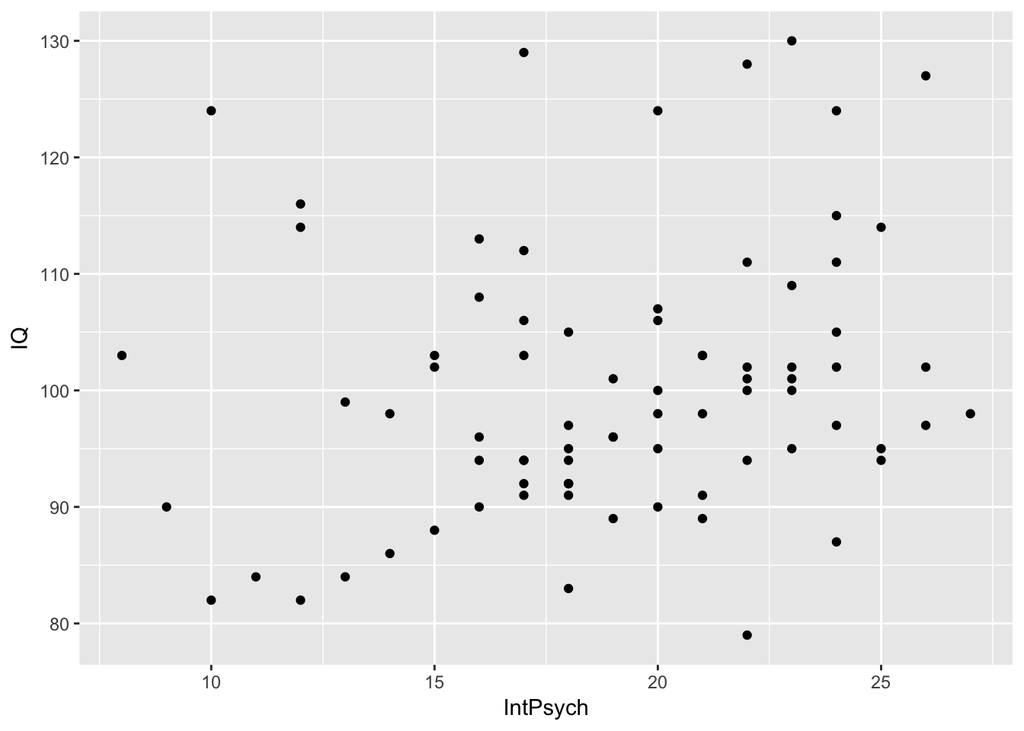

```r
# Remember, we have to load ggplot2 first!
# MT: Style suggestion: always newline after the + in ggplot calls? Makes it a little more readable, and also demonstrates that every new chained command is a LAYER
plot1 <- ggplot(mkData, aes(x=IntPsych, y = IQ)) +
  geom_point()

plot1
```

## 3: Plotting Points By Group

Great, but maybe this isn’t the most helpful format for looking at these data. Let’s say that we want to look at a plot of the points of IntPsych scores by a factor of mother group. It turns out that ggplot handles things nicely when we specific the x axis to be a categorical variable.

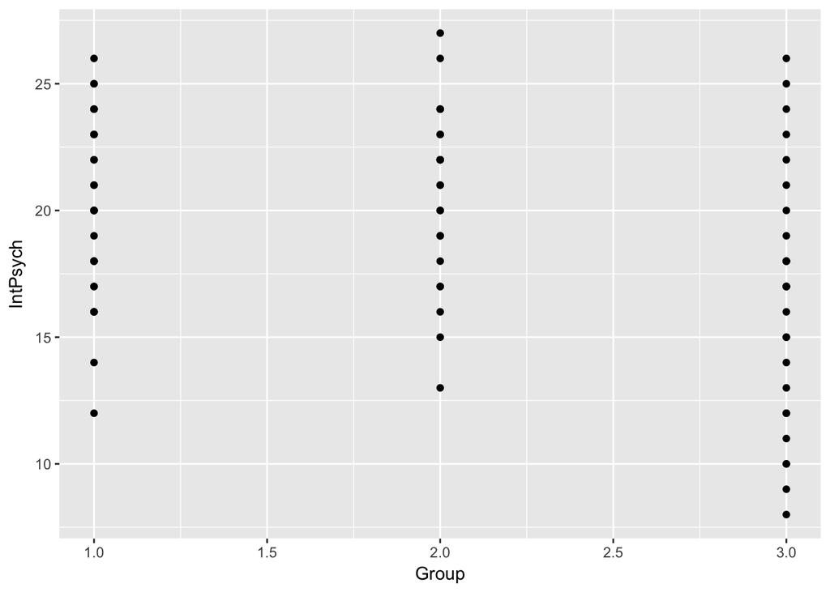

```r
plot2 <- ggplot(mkData, aes(x=Group, y = IntPsych)) +
  geom_point()

plot2
```

Ah, so here’s one important thing to watch out for with ggplot! If we have coded categories with numbers as we have with `Group` here (`Group == 1` control children, `Group == 2` children with bipolar mothers, and `Group == 3` children with schizophrenic mothers), we can see that ggplot automatically interprets this as a continuous numerical variable, rather than categories. We can get around this issue two ways:

1. Coerce the x variable to the factor type by with `x = factor(Group)` instead of just `x = Group`

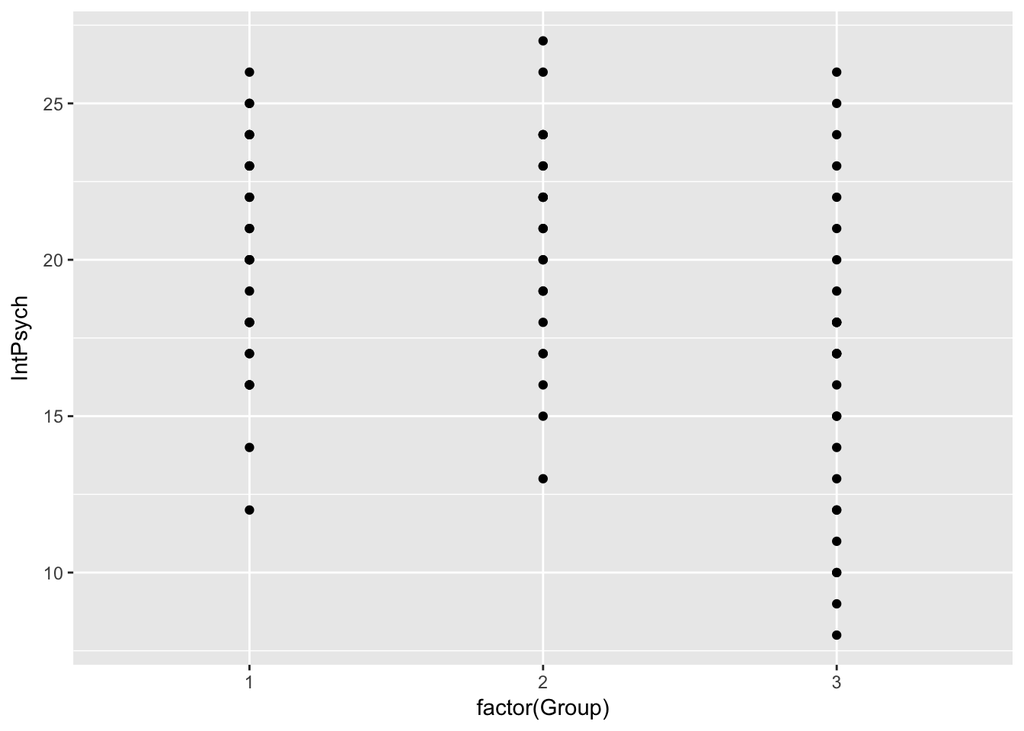

```r
plot3 <- ggplot(mkData, aes(x = factor(Group), y = IntPsych)) +
  geom_point()

plot3
```

```r
# This treats group as a factor, like we want it to, but isn't super helpful for actually making plots where we can understand what the variables mean, because the factors are still called 1, 2, and 3 and not meaningful names.
```

2. Recode the numerically coded categorical variable as strings (better!)

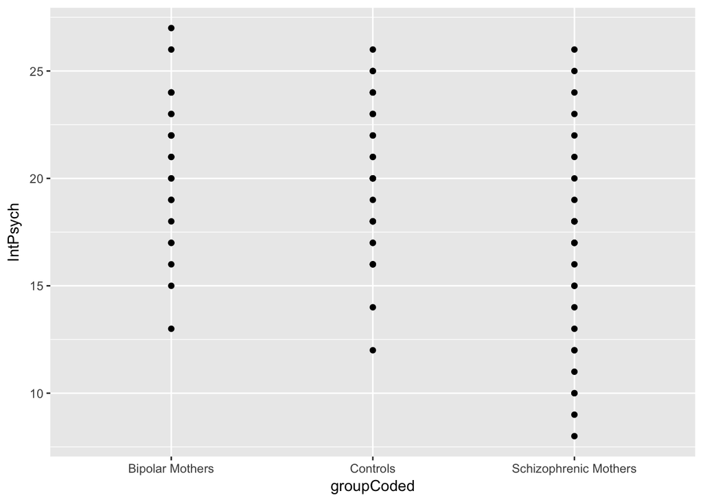

```r
# MT: changed this from using car::recode() to plyr::mapvalues() to recode Group, in keeping within tidyverse
require(plyr)
mkData$groupCoded <- mapvalues(mkData$Group,
                               from = c(1, 2, 3),
                               to = c("Controls", "Bipolar Mothers", "Schizophrenic Mothers"))

# Now, if we plot again, our x variable will both be categorical and have meaningful names!

plot4 <- ggplot(mkData, aes(x=groupCoded, y = IntPsych)) +
  geom_point()

plot4
```

## 4: Plotting Means/Confidence Intervals

Plotting the points to visualize the data is great, but maybe from the plot above we’d like to see means and confidence intervals instead. We can do this using:

MT: Should you explain what the fun.data argument is and what it expects?

`stat_summary(fun.data = "mean_cl_boot")`

There are other arguments we can pass into `stat_summary()` that could give us different summary statistics based on groupings of our data. But we can just look at the mean here.

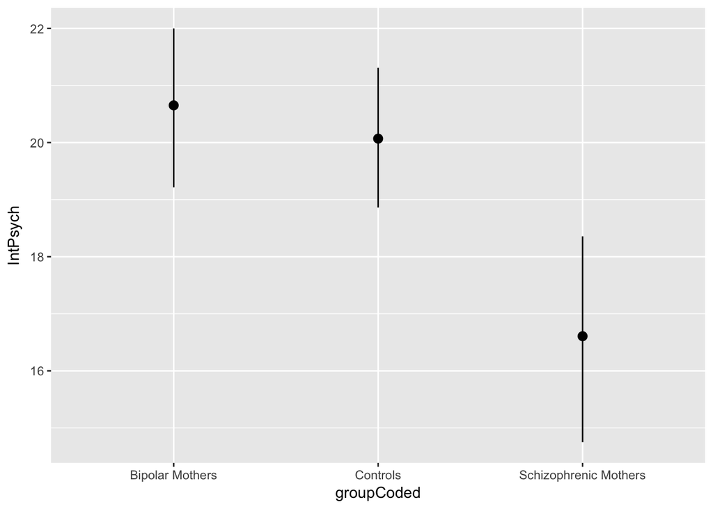

```r
plot5 <- ggplot(mkData, aes(x=groupCoded, y = IntPsych)) +
  stat_summary(fun.data = "mean_cl_boot")

plot5
```

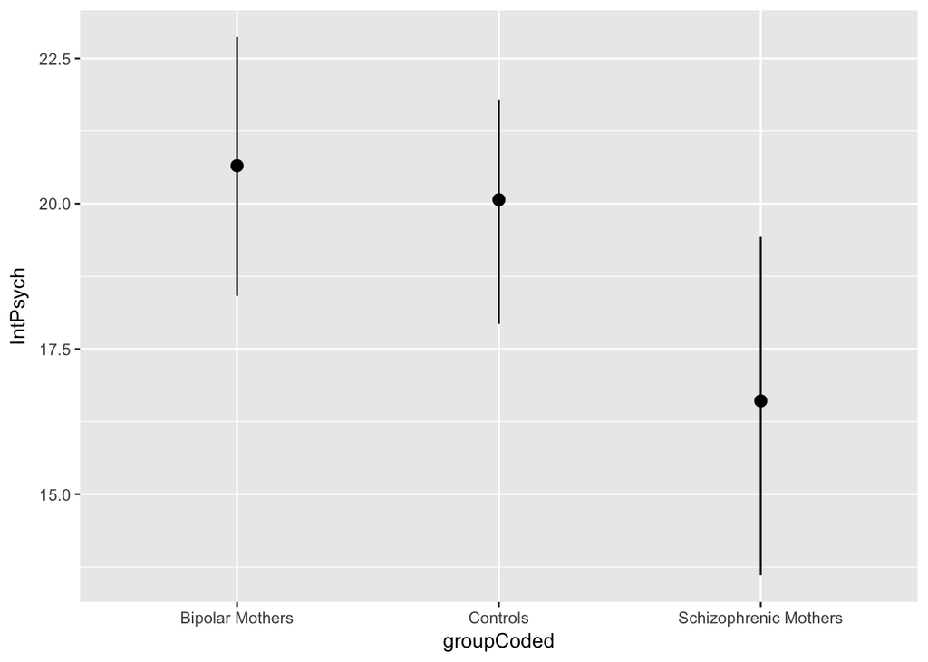

```r
# Let's say we wanted to change the confidence interval to .999...here's a bit of code to edit that
# MT: Reiterating previous comment about explaining the args here? if you think that's useful
plot6 <- ggplot(mkData, aes(x=groupCoded, y = IntPsych)) +
  stat_summary(fun.data = mean_cl_boot, geom = "pointrange", fun.args = list(conf.int = .999))

plot6
```

Pretty cool, but this still doesn’t look so pretty yet. ggplot is pretty great for setting aesthetics of plots, so let’s look into this a litte bit.

## 5: Titles/Axis Labels

Let’s start with labels, because clear axes and titles are important.

Also, a note that we can add things to a plot in a new line with the syntax:

`plot + [newstuff]`.

In general, ggplot is nice because we can just add additional function calls for different purposes to add different things to our plots.

By using `labs()`, we can add labels:

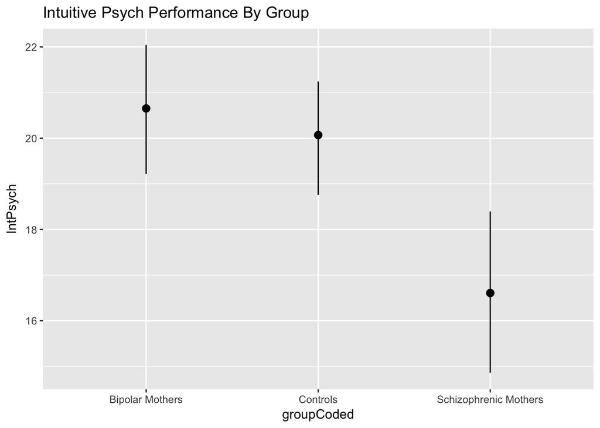

```r
# Title
plot5 + labs(title = "Intuitive Psych Performance By Group")
```

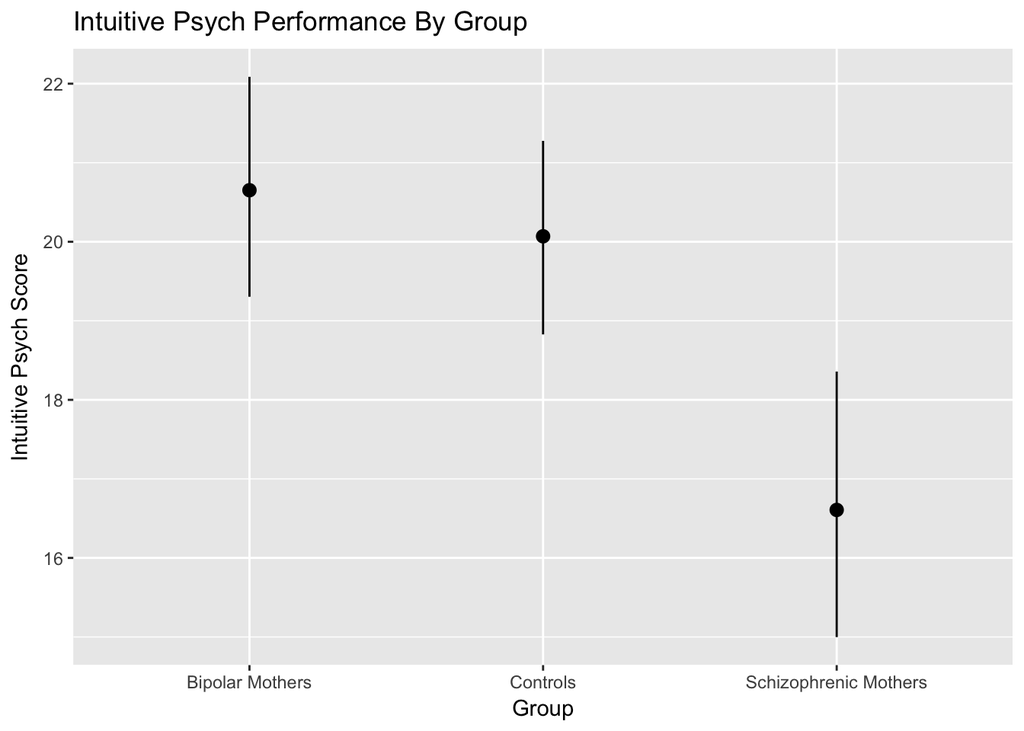

```r
# Axes
plot5 + labs(title = "Intuitive Psych Performance By Group",
             x = "Group",
             y = "Intuitive Psych Score")
```

Often, we also want so specify the ranges of our axes. We can do this using xlim() and ylim(), with each taking the arguments (‘minimum value in range’, ‘maximum value in range’)

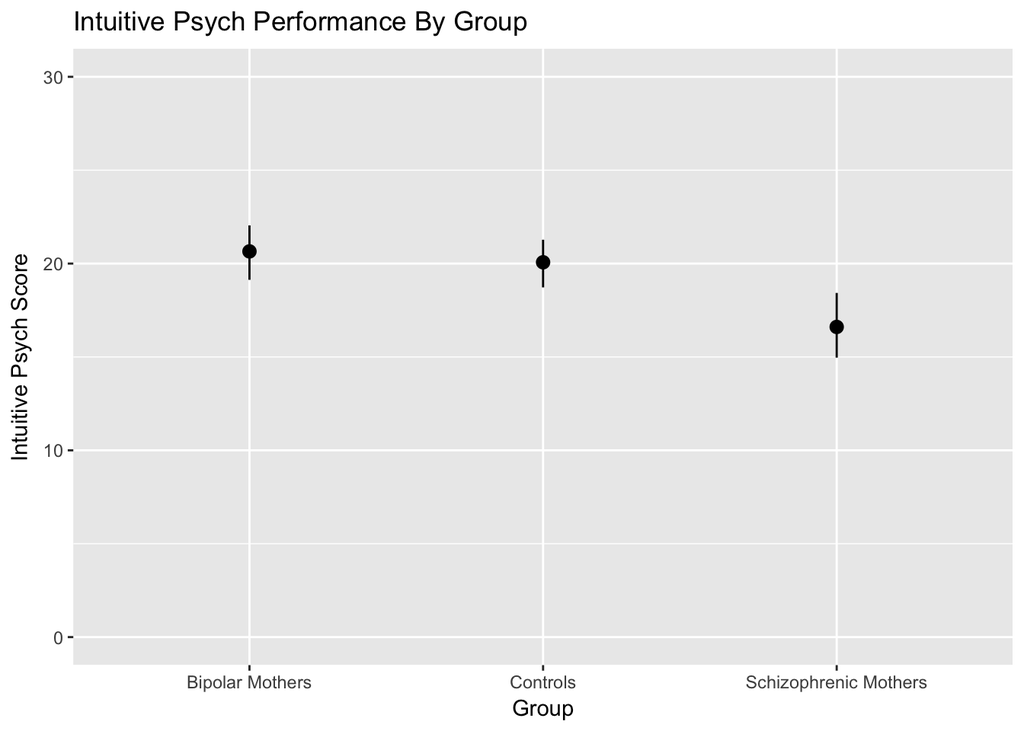

```r
# Adjusting Y Axis Limits using ylim()
plot5 +
  labs(title = "Intuitive Psych Performance By Group",
       x = 'Group',
       y = "Intuitive Psych Score") +
  ylim(0,30)
```

## 6: Color

MT: Changing the arg to specify color in the aes() specs of the ggplot() call to be `color` and not `col` for readability (`col` could be columns if you’re not used to it)

We can use `color = [variable]` to color elements according to either factors with a categorical variable, or on a gradient with a continuous variable.

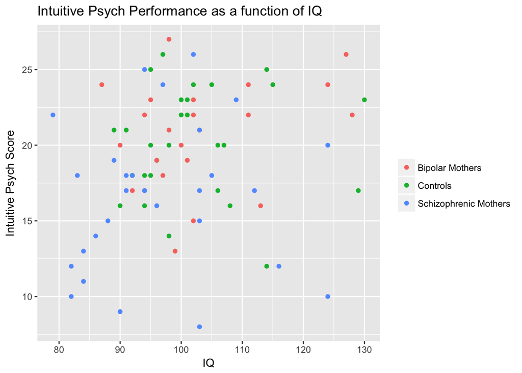

```r
plot7 <- ggplot(mkData, aes(x = IQ, y = IntPsych, color = groupCoded)) +
  geom_point()

plot7 +
  labs(title = "Intuitive Psych Performance as a function of IQ",
       x = 'IQ',
       y = "Intuitive Psych Score") +
  theme(legend.title = element_blank())
```

```r
# We can also put the extra piece of code here at the end to hide an extraneous legend title
```

We can also do continuous color

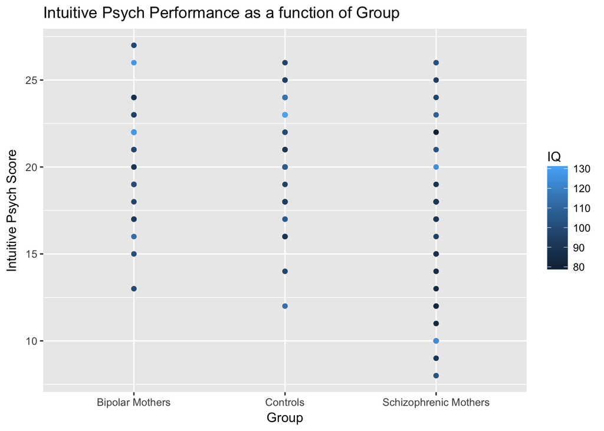

```r
plot5 <- ggplot(mkData, aes(x=groupCoded, y = IntPsych, col = IQ)) +
  geom_point() +
   labs(title = "Intuitive Psych Performance as a function of Group",
        x = 'Group',
        y = "Intuitive Psych Score")

plot5
```

## 7: Fitting A Line

Linear regressions are something we’ll often want to plot. These are really easy in ggplot!

Along with using `geom_point()` as we did before, we can use `geom_smooth()` with arguments `method = "lm"` for a linear model of the data based on the variables you input for x and y. You can also specify a level argument for confidence intervals.

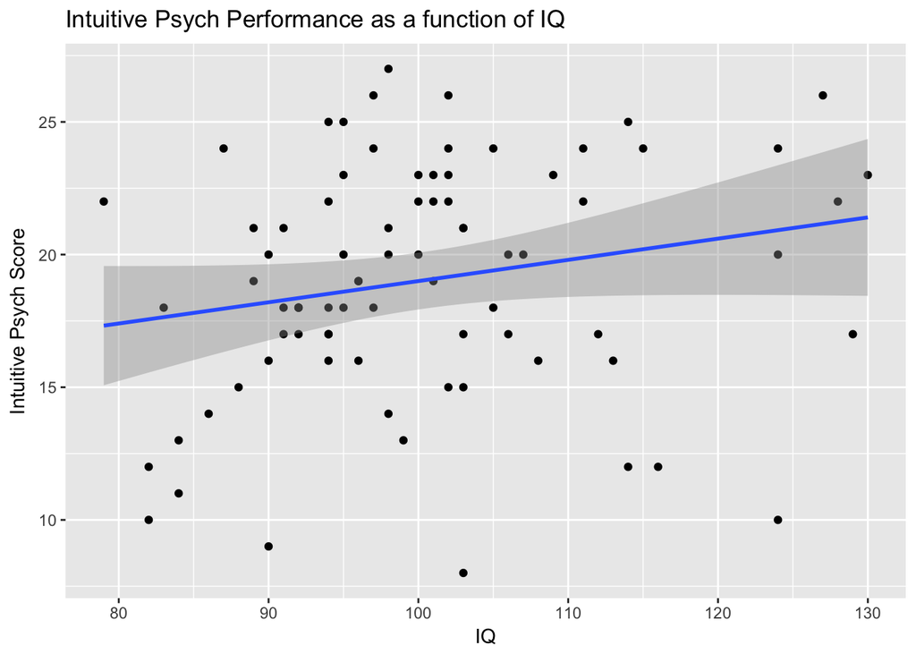

```r
plot7 <- ggplot(mkData, aes(x=IQ, y = IntPsych)) + geom_point()
plot7 +
  labs(title = "Intuitive Psych Performance as a function of IQ",
             x = 'IQ',
             y = "Intuitive Psych Score") +
  theme(legend.title = element_blank()) +
  geom_smooth(method = "lm", level = .97)
```

## 8: Faceting

Sometimes, we want a panel of multiple plots! In ggplot, we can use `facet_wrap("variable")` to make multiple panes of a plot based on levels of a variable.

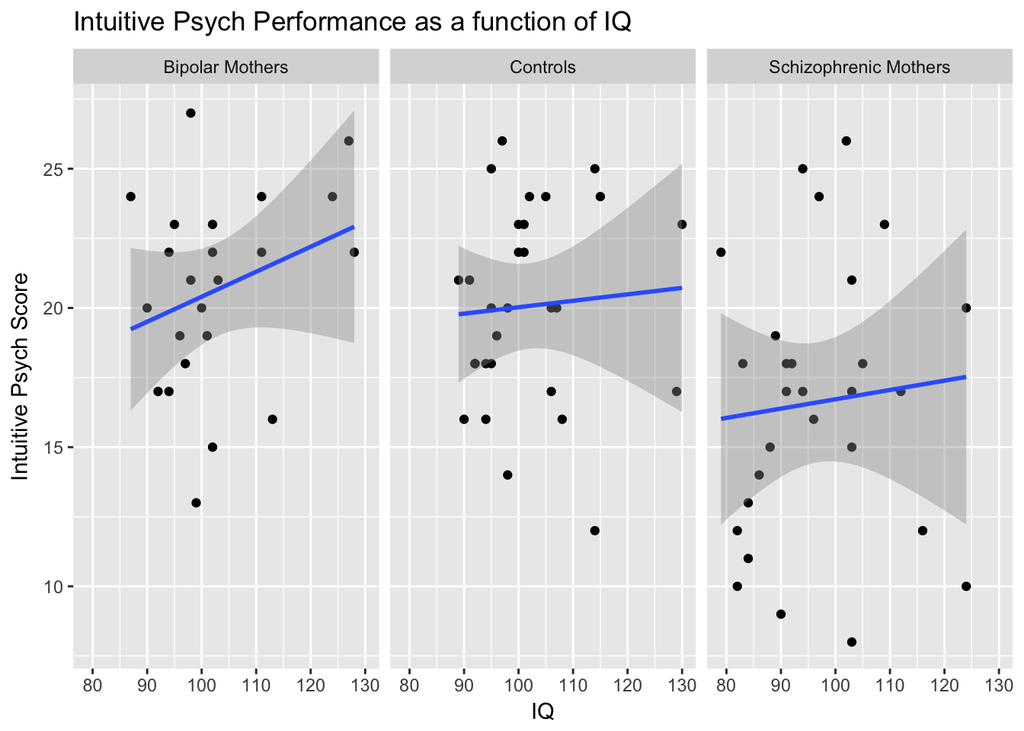

```r
plot7 <- ggplot(mkData, aes(x=IQ, y = IntPsych)) +
  geom_point()
plot7 +
  labs(title = "Intuitive Psych Performance as a function of IQ",
       x = 'IQ',
       y = "Intuitive Psych Score") +
  theme(legend.title = element_blank()) +
  geom_smooth(method = "lm", level = .97) +
  facet_wrap("groupCoded")
```

## 9: Themes

Maybe this shouldn’t be a section of its own, but a lot of people think extraneous grid lines and grey background are annoying. We can change these by using themes. Here’s `theme_bw()` and `theme_classic()`.

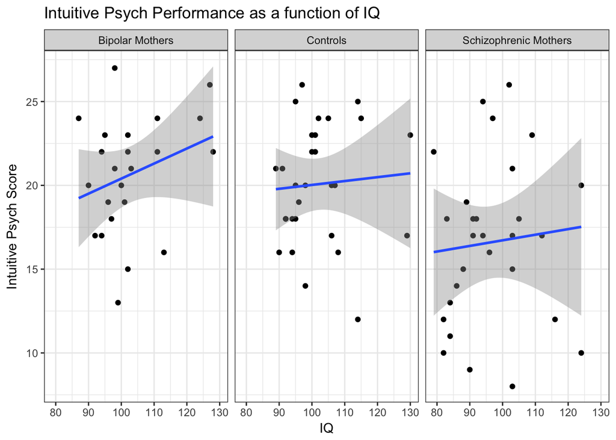

```r
plot7 +
  labs(title = "Intuitive Psych Performance as a function of IQ",
             x = 'IQ',
             y = "Intuitive Psych Score") +
  theme(legend.title = element_blank()) +
  geom_smooth(method = "lm", level = .97) +
  facet_wrap("groupCoded") +
  theme_bw()
```

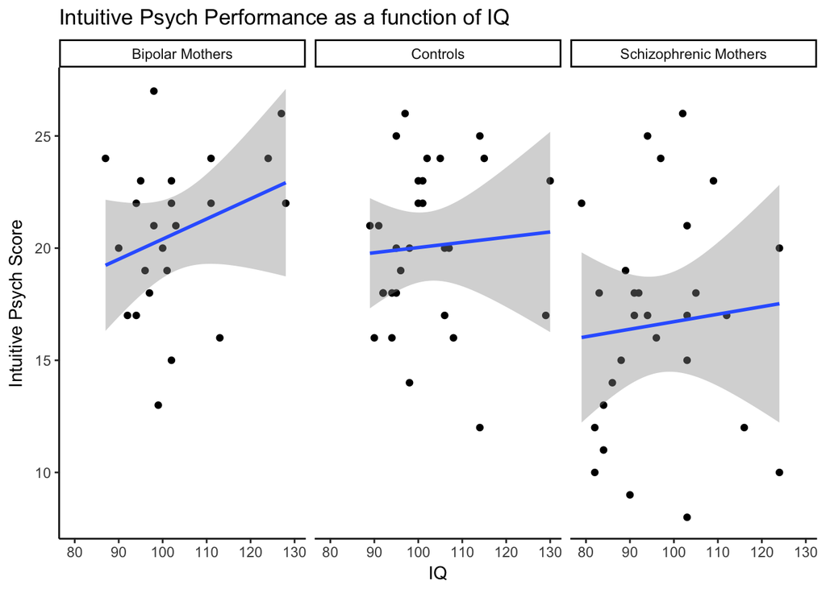

```r
plot7 +
  labs(title = "Intuitive Psych Performance as a function of IQ",
       x = 'IQ',
       y = "Intuitive Psych Score") +
  theme(legend.title = element_blank()) +
  geom_smooth(method = "lm", level = .97) +
  facet_wrap("groupCoded") +
  theme_classic()
```

There are also ways to make only certain gridlines go away or customize more in depth, and even specialized themes (there’s a package that has a FiveThirtyEight theme…) if you want them.